# Descriptive analysis

This page demonstrates the use of **janitor**, **dplyr**, and **gtsummary** to produce tabulations and descriptive statistics, and to conduct simple statistical tests. Each of these tools have advantages and disadvantages in the areas of code simplicity, accessibility of outputs, quality of printed outputs. We hope one of these approaches works for you.

## Preparation

### Load packages

This code chunk shows the loading of packages required for the analyses. In this handbook we emphasize `p_load()` from **pacman**, which installs the package if necessary *and* loads it for use. You can also load installed packages with `library()` from **base** R. See the page on [R basics] for more information on R packages.

```r
pacman::p_load(
  rio,          # File import
  here,         # File locator
  skimr,        # get overview of data
  tidyverse,    # data management + ggplot2 graphics,
  gtsummary,    # summary statistics and tests
  janitor,      # adding totals and percents to tables
  flextable,    # converting tables to HTML
  corrr         # correlation analysis for numeric variables
  )
```

### Import data

```r
# import the linelist
linelist <- import("linelist_cleaned.xlsx")
```

The first 50 rows of the linelist are displayed below.

| case_id | generation | date_infection | date_onset | date_hospitalisation | date_outcome | outcome | gender | age | age_unit | age_years | age_cat | age_cat5 | hospital | lon | lat | infector | source | wt_kg | ht_cm | ct_blood | fever | chills | cough | aches | vomit | temp | time_admission | bmi | days_onset_hosp |
| --- | --- | --- | --- | --- | --- | --- | --- | --- | --- | --- | --- | --- | --- | --- | --- | --- | --- | --- | --- | --- | --- | --- | --- | --- | --- | --- | --- | --- | --- |
| 5fe599 | 4 | 2014-05-08 | 2014-05-13 | 2014-05-15 |  |  | m | 2 | years | 2 | 0-4 | 0-4 | Other | -13.2157351064963 | 8.46897295100924 | f547d6 | other | 27 | 48 | 22 | no | no | yes | no | yes | 36.8 |  | 117.1875 | 2 |
| 8689b7 | 4 |  | 2014-05-13 | 2014-05-14 | 2014-05-18 | Recover | f | 3 | years | 3 | 0-4 | 0-4 | Missing | -13.2152339775486 | 8.45171855856465 |  |  | 25 | 59 | 22 |  |  |  |  |  | 36.9 | 09:36 | 71.8184429761563 | 1 |
| 11f8ea | 2 |  | 2014-05-16 | 2014-05-18 | 2014-05-30 | Recover | m | 56 | years | 56 | 50-69 | 55-59 | St. Mark's Maternity Hospital (SMMH) | -13.212910703914 | 8.46481700596819 |  |  | 91 | 238 | 21 |  |  |  |  |  | 36.9 | 16:48 | 16.0652496292635 | 2 |
| b8812a | 3 | 2014-05-04 | 2014-05-18 | 2014-05-20 |  |  | f | 18 | years | 18 | 15-19 | 15-19 | Port Hospital | -13.2363711169728 | 8.4754761613651 | f90f5f | other | 41 | 135 | 23 | no | no | no | no | no | 36.8 | 11:22 | 22.4965706447188 | 2 |
| 893f25 | 3 | 2014-05-18 | 2014-05-21 | 2014-05-22 | 2014-05-29 | Recover | m | 3 | years | 3 | 0-4 | 0-4 | Military Hospital | -13.2228638912441 | 8.46082377490923 | 11f8ea | other | 36 | 71 | 23 | no | no | yes | no | yes | 36.9 | 12:60 | 71.4144019043841 | 1 |
| be99c8 | 3 | 2014-05-03 | 2014-05-22 | 2014-05-23 | 2014-05-24 | Recover | f | 16 | years | 16 | 15-19 | 15-19 | Port Hospital | -13.222625321098 | 8.46183062600728 | aec8ec | other | 56 | 116 | 21 | no | no | yes | no | yes | 37.6 | 14:13 | 41.6171224732461 | 1 |
| 07e3e8 | 4 | 2014-05-22 | 2014-05-27 | 2014-05-29 | 2014-06-01 | Recover | f | 16 | years | 16 | 15-19 | 15-19 | Missing | -13.2331547837254 | 8.46272931462646 | 893f25 | other | 47 | 87 | 21 |  |  |  |  |  | 37.3 | 14:33 | 62.0953890870657 | 2 |
| 369449 | 4 | 2014-05-28 | 2014-06-02 | 2014-06-03 | 2014-06-07 | Death | f | 0 | years | 0 | 0-4 | 0-4 | Missing | -13.2320975453153 | 8.46144367534271 | 133ee7 | other | 0 | 11 | 22 | no | no | yes | no | yes | 37 | 09:25 | 0 | 1 |
| f393b4 | 4 |  | 2014-06-05 | 2014-06-06 | 2014-06-18 | Recover | m | 61 | years | 61 | 50-69 | 60-64 | Missing | -13.2225511595637 | 8.46191259217774 |  |  | 86 | 226 | 22 | no | no | yes | no | yes | 36.4 | 11:16 | 16.8376536925366 | 1 |
| 1389ca | 4 |  | 2014-06-05 | 2014-06-07 | 2014-06-09 | Death | f | 27 | years | 27 | 20-29 | 25-29 | Missing | -13.2572163655863 | 8.47292327643506 |  |  | 69 | 174 | 22 | no | no | yes | no | no | 35.9 | 10:55 | 22.7903289734443 | 2 |

[output cut: 40 more lines]

## Browse data

### `skimr` package

Using the **skimr** package you can get a detailed and aesthetically pleasing overview of each of the variables in your dataset. Read more about **skimr** at its [github page](https://github.com/ropensci/skimr).

Below, the function `skim()` is applied to the entire `linelist` data frame. An overview of the data frame and a summary of every column (by class) is produced.

```r
## get information about each variable in a dataset
skim(linelist)
```

Data summary

| Name | linelist |
| --- | --- |
| Number of rows | 5888 |
| Number of columns | 30 |
| _______________________ |  |
| Column type frequency: |  |
| character | 13 |
| Date | 4 |
| factor | 2 |
| numeric | 11 |
| ________________________ |  |
| Group variables | None |

**Variable type: character**

| skim_variable | n_missing | complete_rate | min | max | empty | n_unique | whitespace |
| --- | --- | --- | --- | --- | --- | --- | --- |
| case_id | 0 | 1.00 | 6 | 6 | 0 | 5888 | 0 |
| outcome | 1323 | 0.78 | 5 | 7 | 0 | 2 | 0 |
| gender | 278 | 0.95 | 1 | 1 | 0 | 2 | 0 |
| age_unit | 0 | 1.00 | 5 | 6 | 0 | 2 | 0 |
| hospital | 0 | 1.00 | 5 | 36 | 0 | 6 | 0 |
| infector | 2088 | 0.65 | 6 | 6 | 0 | 2697 | 0 |
| source | 2088 | 0.65 | 5 | 7 | 0 | 2 | 0 |
| fever | 249 | 0.96 | 2 | 3 | 0 | 2 | 0 |
| chills | 249 | 0.96 | 2 | 3 | 0 | 2 | 0 |
| cough | 249 | 0.96 | 2 | 3 | 0 | 2 | 0 |
| aches | 249 | 0.96 | 2 | 3 | 0 | 2 | 0 |
| vomit | 249 | 0.96 | 2 | 3 | 0 | 2 | 0 |
| time_admission | 765 | 0.87 | 5 | 5 | 0 | 1072 | 0 |

**Variable type: Date**

| skim_variable | n_missing | complete_rate | min | max | median | n_unique |
| --- | --- | --- | --- | --- | --- | --- |
| date_infection | 2087 | 0.65 | 2014-03-19 | 2015-04-27 | 2014-10-11 | 359 |
| date_onset | 256 | 0.96 | 2014-04-07 | 2015-04-30 | 2014-10-23 | 367 |
| date_hospitalisation | 0 | 1.00 | 2014-04-17 | 2015-04-30 | 2014-10-23 | 363 |
| date_outcome | 936 | 0.84 | 2014-04-19 | 2015-06-04 | 2014-11-01 | 371 |

**Variable type: factor**

| skim_variable | n_missing | complete_rate | ordered | n_unique | top_counts |
| --- | --- | --- | --- | --- | --- |
| age_cat | 86 | 0.99 | FALSE | 8 | 0-4: 1095, 5-9: 1095, 20-: 1073, 10-: 941 |
| age_cat5 | 86 | 0.99 | FALSE | 17 | 0-4: 1095, 5-9: 1095, 10-: 941, 15-: 743 |

**Variable type: numeric**

| skim_variable | n_missing | complete_rate | mean | sd | p0 | p25 | p50 | p75 | p100 |
| --- | --- | --- | --- | --- | --- | --- | --- | --- | --- |
| generation | 0 | 1.00 | 16.56 | 5.79 | 0.00 | 13.00 | 16.00 | 20.00 | 37.00 |
| age | 86 | 0.99 | 16.07 | 12.62 | 0.00 | 6.00 | 13.00 | 23.00 | 84.00 |
| age_years | 86 | 0.99 | 16.02 | 12.64 | 0.00 | 6.00 | 13.00 | 23.00 | 84.00 |
| lon | 0 | 1.00 | -13.23 | 0.02 | -13.27 | -13.25 | -13.23 | -13.22 | -13.21 |
| lat | 0 | 1.00 | 8.47 | 0.01 | 8.45 | 8.46 | 8.47 | 8.48 | 8.49 |
| wt_kg | 0 | 1.00 | 52.64 | 18.58 | -11.00 | 41.00 | 54.00 | 66.00 | 111.00 |
| ht_cm | 0 | 1.00 | 124.96 | 49.52 | 4.00 | 91.00 | 129.00 | 159.00 | 295.00 |
| ct_blood | 0 | 1.00 | 21.21 | 1.69 | 16.00 | 20.00 | 22.00 | 22.00 | 26.00 |
| temp | 149 | 0.97 | 38.56 | 0.98 | 35.20 | 38.20 | 38.80 | 39.20 | 40.80 |
| bmi | 0 | 1.00 | 46.89 | 55.39 | -1200.00 | 24.56 | 32.12 | 50.01 | 1250.00 |
| days_onset_hosp | 256 | 0.96 | 2.06 | 2.26 | 0.00 | 1.00 | 1.00 | 3.00 | 22.00 |

You can also use the `summary()` function, from **base** R, to get information about an entire data sets, but this output can be more difficult to read than using **skimr**.

```r
## get information about each column in a dataset
summary(linelist)
```

### Summary statistics

You can use **base** R functions to return summary statistics on a numeric column. These functions are also often used within more complex code operations, for example if grouping and summarising columns, or referencing a `max()` value to calibrate plot height.

See the [R basics] page for a complete list of mathematical operators such as `max()`, `min()`, `median()`, `mean()`, `quantile()`, `sd()`, and `range()`.

*CAUTION:* If your data contain missing values, R wants you to know this and so will return `NA` unless you specify to the above mathematical functions that you want R to ignore missing values, via the argument `na.rm = TRUE`.

You can return most of the useful summary statistics for a numeric column using `summary()`, as below. Note that the dataframe must also be specified as shown below.

```r
summary(linelist$age_years)
```

```
##    Min. 1st Qu.  Median    Mean 3rd Qu.    Max.    NA's
##    0.00    6.00   13.00   16.02   23.00   84.00      86
```

You can access and save one specific part of it with index brackets [ ]:

```r
summary(linelist$age_years)[[2]]
```

```
## [1] 6
```

## Descriptive tables

You have several choices when producing tabulation and cross-tabulation summary tables. Some of the factors to consider include code simplicity and ease, the desired output (printed to R console, or as pretty HTML), and what you can do with the data afterward. Consider the thoughts below as you choose the tool for your situation.

- Use `tabyl()` from **janitor** to produce and "adorn" tabulations and cross-tabulations
- Cons: requires post-processing (e.g with **flextable**) for publication ready tables. Does not accept multiple variables (need to use **purrr** to iterate)
- Use `count()` and `summarise()` from **dplyr** if preparing data for `ggplot()` or calculating more complex statistics
- Cons: similar to above but requires even more manipulation
- Use `tbl_summary()` from **gtsummary** to produce detailed publication-ready tables
- Cons: missings not automatically included in percentage calculations. To use for plotting need to extract tibble from list output.

### **janitor**

The **janitor** packages offers the `tabyl()` function which produces clean tabulations and cross-tabulations, which can be "adorned" or modified with other functions to display percents, proportions, etc.

Below, we pipe the `linelist` data frame to **janitor** functions and print the result. If desired, you can also save the resulting tables with the assignment operator `<-`.

#### Simple tabyl

The default use of `tabyl()` on a specific column produces the unique values, counts, and column-wise "percents" (actually proportions). The proportions may have many digits. You can adjust this with `adorn_rounding()` as described below.

```r
linelist %>%
  tabyl(age_cat)
```

```
##  age_cat    n     percent valid_percent
##      0-4 1095 0.185971467   0.188728025
##      5-9 1095 0.185971467   0.188728025
##    10-14  941 0.159816576   0.162185453
##    15-19  743 0.126188859   0.128059290
##    20-29 1073 0.182235054   0.184936229
##    30-49  754 0.128057065   0.129955188
##    50-69   95 0.016134511   0.016373664
##      70+    6 0.001019022   0.001034126
##     <NA>   86 0.014605978            NA
```

As you can see above, if there are missing values they display in a row labeled `<NA>`. You can suppress them with `show_na = FALSE`. If there are no missing values, this row will not appear. If there are missing values, proportions are given as both raw (denominator inclusive of `NA` counts) and "valid" (denominator excludes `NA` counts).

If the column is class Factor and only certain levels are present in your data, they will still appear in the table. You can suppress this feature with `show_missing_levels = FALSE`.

#### Cross-tabulation

Cross-tabulation counts are achieved by adding one or more additional within `tabyl()`. Note that only counts are returned - proportions and percents can be added with additional steps.

```r
linelist %>%
  tabyl(age_cat, gender)
```

```
##  age_cat   f   m NA_
##      0-4 640 416  39
##      5-9 641 412  42
##    10-14 518 383  40
##    15-19 359 364  20
##    20-29 468 575  30
##    30-49 179 557  18
##    50-69   2  91   2
##      70+   0   5   1
##     <NA>   0   0  86
```

#### "Adorning" the tabyl

Use **janitor**'s "adorn" functions to add totals or convert to proportions, percents, or otherwise adjust the display. Often you will pipe the tabyl through multiple of these functions.

| Function | Outcome |
| --- | --- |
| `adorn_totals()` | Adds totals (`where =` "row", "col", or "both"). Set `name =` for "Total". |
| `adorn_percentages()` | Convert counts to proportions, with `denominator =` "row", "col", or "all" |
| `adorn_pct_formatting()` | Converts proportions to percents. Specify `digits =`. Remove "%" with `affix_sign = F`. |
| `adorn_rounding()` | To round counts, proportions to `digits =` places. To round percents use `adorn_pct_formatting()` as above. |
| `adorn_ns()` | Add counts to a table of proportions or percents. Indicate `position =` "rear" for counts in parentheses, or "front" to put the percent in parentheses. |
| `adorn_title()` | add string `row_name =` and/or `col_name =` |

Be conscious of the order you apply the above functions. Below are some examples.

A simple one-way table with percents instead of the default proportions.

```r
linelist %>%               # case linelist
  tabyl(age_cat) %>%       # tabulate counts and proportions by age category
  adorn_pct_formatting()   # convert proportions to percents
```

```
##  age_cat    n percent valid_percent
##      0-4 1095   18.6%         18.9%
##      5-9 1095   18.6%         18.9%
##    10-14  941   16.0%         16.2%
##    15-19  743   12.6%         12.8%
##    20-29 1073   18.2%         18.5%
##    30-49  754   12.8%         13.0%
##    50-69   95    1.6%          1.6%
##      70+    6    0.1%          0.1%
##     <NA>   86    1.5%             -
```

A cross-tabulation with a total row and row percents.

```r
linelist %>%
  tabyl(age_cat, gender) %>%                  # counts by age and gender
  adorn_totals(where = "row") %>%             # add total row
  adorn_percentages(denominator = "row") %>%  # convert counts to proportions
  adorn_pct_formatting(digits = 1)            # convert proportions to percents
```

```
##  age_cat     f     m    NA_
##      0-4 58.4% 38.0%   3.6%
##      5-9 58.5% 37.6%   3.8%
##    10-14 55.0% 40.7%   4.3%
##    15-19 48.3% 49.0%   2.7%
##    20-29 43.6% 53.6%   2.8%
##    30-49 23.7% 73.9%   2.4%
##    50-69  2.1% 95.8%   2.1%
##      70+  0.0% 83.3%  16.7%
##     <NA>  0.0%  0.0% 100.0%
##    Total 47.7% 47.6%   4.7%
```

A cross-tabulation adjusted so that both counts and percents are displayed.

```r
linelist %>%                                  # case linelist
  tabyl(age_cat, gender) %>%                  # cross-tabulate counts
  adorn_totals(where = "row") %>%             # add a total row
  adorn_percentages(denominator = "col") %>%  # convert to proportions
  adorn_pct_formatting() %>%                  # convert to percents
  adorn_ns(position = "front") %>%            # display as: "count (percent)"
  adorn_title(                                # adjust titles
    row_name = "Age Category",
    col_name = "Gender")
```

```
##                      Gender
##  Age Category             f             m          NA_
##           0-4  640  (22.8%)  416  (14.8%)  39  (14.0%)
##           5-9  641  (22.8%)  412  (14.7%)  42  (15.1%)
##         10-14  518  (18.5%)  383  (13.7%)  40  (14.4%)
##         15-19  359  (12.8%)  364  (13.0%)  20   (7.2%)
##         20-29  468  (16.7%)  575  (20.5%)  30  (10.8%)
##         30-49  179   (6.4%)  557  (19.9%)  18   (6.5%)
##         50-69    2   (0.1%)   91   (3.2%)   2   (0.7%)
##           70+    0   (0.0%)    5   (0.2%)   1   (0.4%)
##          <NA>    0   (0.0%)    0   (0.0%)  86  (30.9%)
##         Total 2807 (100.0%) 2803 (100.0%) 278 (100.0%)
```

#### Printing the tabyl

By default, the tabyl will print raw to your R console. Alternatively, you can pass the tabyl to **flextable** or other package to print as HTML in the RStudio Viewer. Note that if using `adorn_titles()`, you must specify `placement = "combined"` in order to print in this manner.

```r
linelist %>%
  tabyl(age_cat, gender) %>%
  adorn_totals(where = "col") %>%
  adorn_percentages(denominator = "col") %>%
  adorn_pct_formatting() %>%
  adorn_ns(position = "front") %>%
  adorn_title(
    row_name = "Age Category",
    col_name = "Gender",
    placement = "combined") %>% # this is necessary to print to HTML
  flextable::flextable() %>%    # convert to HTML
  flextable::autofit()          # format to one line per row
```

| Age Category/Gender | f | m | NA_ | Total |
| --- | --- | --- | --- | --- |
| 0-4 | 640 (22.8%) | 416 (14.8%) | 39 (14.0%) | 1095 (18.6%) |
| 5-9 | 641 (22.8%) | 412 (14.7%) | 42 (15.1%) | 1095 (18.6%) |
| 10-14 | 518 (18.5%) | 383 (13.7%) | 40 (14.4%) | 941 (16.0%) |
| 15-19 | 359 (12.8%) | 364 (13.0%) | 20 (7.2%) | 743 (12.6%) |
| 20-29 | 468 (16.7%) | 575 (20.5%) | 30 (10.8%) | 1073 (18.2%) |
| 30-49 | 179 (6.4%) | 557 (19.9%) | 18 (6.5%) | 754 (12.8%) |
| 50-69 | 2 (0.1%) | 91 (3.2%) | 2 (0.7%) | 95 (1.6%) |
| 70+ | 0 (0.0%) | 5 (0.2%) | 1 (0.4%) | 6 (0.1%) |
|  | 0 (0.0%) | 0 (0.0%) | 86 (30.9%) | 86 (1.5%) |

#### Use on other tables

You can use **janitor**'s `adorn_*()` functions on other tables, such as those created by `summarise()`, `count()`, or `table()`.

#### Saving the tabyl

If you convert the table to HTML with a package like **flextable**, you can save it with functions `save_as_html()`, `save_as_word()`, `save_as_ppt`, and `save_as_image()`, as discussed more extensively in the [Tables for presentation] page. Below, the table is saved as a Word document in which it can be hand-edited.

[figure not shown]

```r
linelist %>%
  tabyl(age_cat, gender) %>%
  adorn_totals(where = "col") %>%
  adorn_percentages(denominator = "col") %>%
  adorn_pct_formatting() %>%
  adorn_ns(position = "front") %>%
  adorn_title(
    row_name = "Age Category",
    col_name = "Gender",
    placement = "combined") %>%
  flextable::flextable() %>%                     # convert to HTML flextable
  flextable::autofit() %>%                       # ensure only one line per row
  flextable::save_as_docx(path = "tabyl.docx")   # save as Word document
```

#### Statistics

You can apply statistical tests on tabyls, like `chisq.test()` or `fisher.test()` from **stats** as shown below. Note missing values are not allowed.

```r
age_by_outcome <- linelist %>%
  tabyl(age_cat, outcome, show_na = FALSE)

chisq.test(age_by_outcome)
```

```
##
##  Pearson's Chi-squared test
##
## data:  age_by_outcome
## X-squared = 6.4931, df = 7, p-value = 0.4835
```

#### Other tips

- Include the argument `na.rm = TRUE` to exclude missing values from any of the above calculations.
- If applying `adorn_XXX()` to tables not created by `tabyl()`, you can specify particular column(s) to apply to like `adorn_percentage(,,,c(cases,deaths))`. The syntax is not simple. Consider using `summarise()` instead.
- You can read more detail in the [janitor page](https://cran.r-project.org/web/packages/janitor/vignettes/janitor.html) and the [tabyl vignette](https://cran.r-project.org/web/packages/janitor/vignettes/tabyls.html).

### **dplyr** package

**dplyr** is part of the **tidyverse** packages and is an extremely common data management tool. Creating tables with **dplyr** is useful if you are calculating summary statistics by group, or passing the results to `ggplot()` (which expects "long" data).

#### Counts

As explained in the [Grouping data] page, you can use the **dplyr** function `count()` to return tabulated counts on one or more columns. The output returned is in a "long" format with a column `n` to hold the counts.

```r
linelist %>%
  count(age_cat)
```

```
##   age_cat    n
## 1     0-4 1095
## 2     5-9 1095
## 3   10-14  941
## 4   15-19  743
## 5   20-29 1073
## 6   30-49  754
## 7   50-69   95
## 8     70+    6
## 9    <NA>   86
```

Tabulations of two or more columns are still returned in "long" format, with the counts in the `n` column.

```r
linelist %>%
  count(age_cat, gender)
```

```
##    age_cat gender   n
## 1      0-4      f 640
## 2      0-4      m 416
## 3      0-4   <NA>  39
## 4      5-9      f 641
## 5      5-9      m 412
## 6      5-9   <NA>  42
## 7    10-14      f 518
## 8    10-14      m 383
## 9    10-14   <NA>  40
## 10   15-19      f 359
## 11   15-19      m 364
## 12   15-19   <NA>  20
## 13   20-29      f 468
## 14   20-29      m 575
## 15   20-29   <NA>  30
## 16   30-49      f 179
## 17   30-49      m 557
## 18   30-49   <NA>  18
## 19   50-69      f   2
## 20   50-69      m  91
## 21   50-69   <NA>   2
## 22     70+      m   5
## 23     70+   <NA>   1
## 24    <NA>   <NA>  86
```

To display this output of counts by group with `ggplot()` is relatively straight-forward. See further examples in the pages [Plotting categorical data] and [ggplot tips].

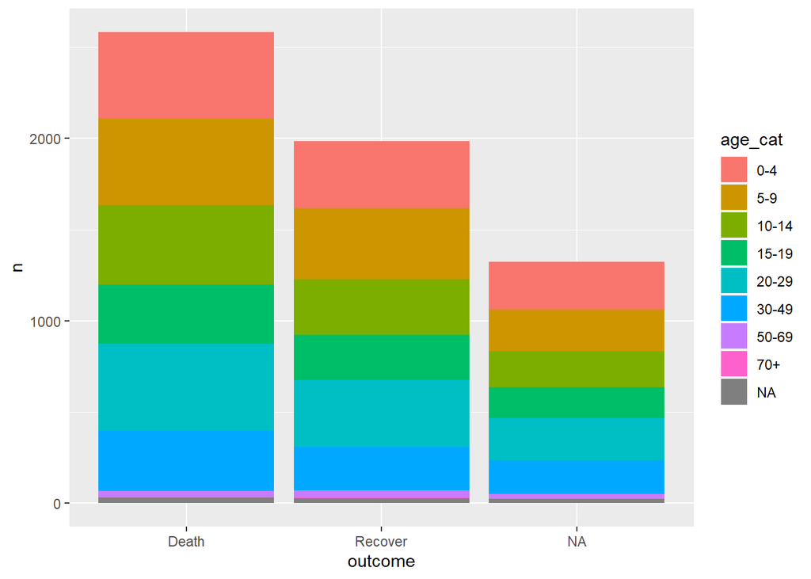

```r
linelist %>%
  count(outcome, age_cat) %>%
  ggplot()+
    geom_bar(aes(x = outcome, fill = age_cat, y = n), stat = "identity")
```

#### Within-group proportions

You can calculate proportions *within groups* by having two levels of aggregation prior to using `mutate()`. The table below first groups the data frame by `outcome` and then groups again and counts by column `age_cat`, achieving the breakdown of age *by outcome*. Note that you can add more stratifications by adding columns to the `group_by()` command.

```r
age_by_outcome <- linelist %>%
  group_by(outcome) %>%                  # group first by outcome
  count(age_cat) %>%                     # group again and count by gender (produces "n" column)
  mutate(percent = scales::percent(n / sum(n))) # calculate percent - note the denominator is by outcome group
```

| outcome | age_cat | n | percent |
| --- | --- | --- | --- |
| Death | 0-4 | 471 | 18.242% |
| Death | 5-9 | 476 | 18.435% |
| Death | 10-14 | 438 | 16.964% |
| Death | 15-19 | 323 | 12.510% |
| Death | 20-29 | 477 | 18.474% |
| Death | 30-49 | 329 | 12.742% |
| Death | 50-69 | 33 | 1.278% |
| Death | 70+ | 3 | 0.116% |
| Death |  | 32 | 1.239% |
| Recover | 0-4 | 364 | 18.36% |

[output cut: 16 more lines]

#### Pivot wider

If your **dplyr** table is in "long" format, you can "pivot" it to wide format using the **tidyr** `pivot_wider()` function. You will likely need to re-define the column names with `rename()`. For more information see the page on [Pivoting data].

```r
age_by_outcome %>%
  pivot_wider(names_from = age_cat, values_from = c(n, percent))
```

```
## # A tibble: 3 x 19
## # Groups:   outcome [3]
##   outcome `n_0-4` `n_5-9` `n_10-14` `n_15-19` `n_20-29` `n_30-49` `n_50-69`
##   <chr>     <int>   <int>     <int>     <int>     <int>     <int>     <int>
## 1 Death       471     476       438       323       477       329        33
## 2 Recover     364     391       303       251       367       238        38
## 3 <NA>        260     228       200       169       229       187        24
## # ... with 11 more variables: `n_70+` <int>, n_NA <int>, `percent_0-4` <chr>,
## #   `percent_5-9` <chr>, `percent_10-14` <chr>, `percent_15-19` <chr>,
## #   `percent_20-29` <chr>, `percent_30-49` <chr>, `percent_50-69` <chr>,
## #   `percent_70+` <chr>, percent_NA <chr>
```

#### Summary statistics with `summarise()`

One of the advantages of using **dplyr** to make your table is the flexibility to calculate statistics like `median()`, `max()`, `sd()`, within the context of `summarise()`. These statistics can be calculated for the whole dataset or by group. `summarise()` creates a *new* summary data frame consisting of only the columns you define within `summarise()` (and any grouping columns).

Within the summarise statement, provide the name(s) of each **new** summary column, an equals sign, and then a statistical function to apply. Within the statistical function, list the column to be operated on and any relevant argument (e.g. `na.rm = TRUE`). You can use `sum()` to count the number of rows that meet a logical criteria (use double equals `==`).

Below, `linelist` data on the delay from symptom onset to hospital admission (column `days_onset_hosp`, in days) are summarised.

```r
summary_table <- linelist %>%                                        # begin with linelist, save out as new object
  group_by(hospital) %>%                                             # Group all calculations by hospital
  summarise(                                                         # only these summary columns will be returned
    cases       = n(),                                                # number of rows per group
    delay_3     = sum(days_onset_hosp >= 3, na.rm = T),               # number of rows with male gender
    pct_delay_3 = scales::percent(delay_3 / cases),                   # convert previously-defined column to percent
    delay_mean  = round(mean(days_onset_hosp, na.rm=T), digits = 1),  # mean of delays column, by group and rounded
    delay_sd    = round(sd(days_onset_hosp, na.rm = T), digits = 1)   # standard deviation of delays, by group and rounded
  )

summary_table  # print
```

```
## # A tibble: 6 x 6
##   hospital                         cases delay_3 pct_delay_3 delay_mean delay_sd
##   <chr>                            <int>   <int> <chr>            <dbl>    <dbl>
## 1 Central Hospital                   454     108 24%                1.9      1.9
## 2 Military Hospital                  896     253 28%                2.1      2.4
## 3 Missing                           1469     399 27%                2.1      2.3
## 4 Other                              885     234 26%                2        2.2
## 5 Port Hospital                     1762     470 27%                2.1      2.2
## 6 St. Mark's Maternity Hospital (~   422     116 27%                2.1      2.3
```

Some tips:

- Use `sum()` with a logic statement within to "count" rows that meet certain criteria
- Note the use of argument `na.rm = TRUE` in mathematical functions like `sum()`, otherwise `NA` will be returned if there are any missing values
- Use the function `percent()` from the **scales** package to easily convert to percents
- Use `round()` from **base** R to specify decimals
- To calculate these statistics on the entire dataset, use `summarise()` without `group_by()`

Percentiles deserve a special mention. To return percentiles, use `quantile()` with the defaults or specify the value(s) you would like with `probs =`.

```r
# get default percentile values of age (0%, 25%, 50%, 75%, 100%)
linelist %>%
  summarise(age_percentiles = quantile(age_years, na.rm = TRUE))
```

```
##   age_percentiles
## 1               0
## 2               6
## 3              13
## 4              23
## 5              84
```

```r
# get specified percentile values of age (5%, 50%, 75%, 98%)
linelist %>%
  summarise(
    age_percentiles = quantile(
      age_years,
      probs = c(.05, 0.5, 0.75, 0.98),
      na.rm=TRUE)
    )
```

```
##   age_percentiles
## 1               1
## 2              13
## 3              23
## 4              48
```

You can also use `str_glue()` to combine columns into one new column - typically used *after* the `summarise()` command. Below, the `summary_table` data frame created above is mutated such that columns `delay_mean` and `delay_sd` are combined and their old columns removed. Then, to make the table more presentable, a total row is added with `adorn_totals()` from **janitor** (which ignores non-numeric columns). Lastly, we use `rename()` from **dplyr** to make the column names nicer. Now you could pass to **flextable** and print to Word, HTML, Powerpoint, etc.!

```r
summary_table %>%
  mutate(delay = str_glue("{delay_mean} ({delay_sd})")) %>%  # combine and format other values
  select(-c(delay_mean, delay_sd)) %>%                       # remove two old columns
  adorn_totals(where = "row") %>%                            # add total row
  rename(                                                    # rename cols
    "Hospital Name"   = hospital,
    "Cases"           = cases,
    "Delay 3+ days"   = delay_3,
    "% delay 3+ days" = pct_delay_3,
    "Mean (sd)"       = delay)
```

```
##                         Hospital Name Cases Delay 3+ days % delay 3+ days
##                      Central Hospital   454           108             24%
##                     Military Hospital   896           253             28%
##                               Missing  1469           399             27%
##                                 Other   885           234             26%
##                         Port Hospital  1762           470             27%
##  St. Mark's Maternity Hospital (SMMH)   422           116             27%
##                                 Total  5888          1580               -
##  Mean (sd)
##  1.9 (1.9)
##  2.1 (2.4)
##  2.1 (2.3)
##    2 (2.2)
##  2.1 (2.2)
##  2.1 (2.3)
##          -
```

#### Using `summarise()` on aggregated data

*If you begin with aggregated data*, use `sum()` on the counts column. For example, let's say you are beginning with the table of counts below, called `linelist_agg` - it shows in "long" format the case counts by outcome and gender.

```
##   outcome gender    n
## 1   Death      f 1227
## 2   Death      m 1228
## 3 Recover      f  953
## 4 Recover      m  950
```

To sum the count values (in column `n`) by group you can use `sum(n, na.rm=T)`. To sum those values by the grouping column *and within that by a specific subset*, you can use the subset bracket [ ] syntax on the count column as below:

```r
linelist_agg %>%
  group_by(outcome) %>%
  summarise(
    total_cases = sum(n, na.rm=T),
    male_cases = sum(n[gender == "m"], na.rm=T),
    female_cases = sum(n[gender == "f"], na.rm=T))
```

```
## # A tibble: 2 x 4
##   outcome total_cases male_cases female_cases
##   <chr>         <int>      <int>        <int>
## 1 Death          2455       1228         1227
## 2 Recover        1903        950          953
```

**_TIP:_** The summarise function works with both UK and US spelling - `summarise()` and `summarize()` call the same function.

#### Summarise `across()` multiple columns

You can use summarise across multiple columns using `across()`. This makes life easier when you want the same statistic for many columns. To specify which columns to operate across, either:

- Provide a vector of column names `c()`, or
- Use the `select()` semantic helper functions (explained below) to select columns by criteria

Below, `mean()` is applied to grouped data. The columns are specified, a function is specified (no parentheses), and finally, any additional arguments for the function (e.g. `na.rm=TRUE`).

It can be difficult to get the order of parentheses and commas correct when using `across()`. Remember that within `across()` you must include the columns, the functions, and any extra arguments needed for the functions.

```r
linelist %>%
  group_by(outcome) %>%
  summarise(across(.cols = c(age_years, temp, wt_kg, ht_cm),
                   .fns = mean,
                   na.rm=T))
```

```
## # A tibble: 3 x 5
##   outcome age_years  temp wt_kg ht_cm
##   <chr>       <dbl> <dbl> <dbl> <dbl>
## 1 Death        15.9  38.6  52.6  125.
## 2 Recover      16.1  38.6  52.5  125.
## 3 <NA>         16.2  38.6  53.0  125.
```

Here are those `select()` helper functions that you can place *within* `across()`:

These are helper functions available to assist you in specifying columns:

- `everything()` - all other columns not mentioned
- `last_col()` - the last column
- `where()` - applies a function to all columns and selects those which are TRUE
- `starts_with()` - matches to a specified prefix. Example: `starts_with("date")`
- `ends_with()` - matches to a specified suffix. Example: `ends_with("_end")`
- `contains()` - columns containing a character string. Example: `contains("time")`
- `matches()` - to apply a regular expression (regex). Example: `contains("[pt]al")`
- `num_range()` -
- `any_of()` - matches if column is named. Useful if the name might not exist. Example: `any_of(date_onset, date_death, cardiac_arrest)`

For example, to return the mean of every numeric column. The `where()` command takes the place of a vector of column names `c()`. The function and any additional arguments are all within the `across()`.

```r
linelist %>%
  group_by(outcome) %>%
  summarise(across(.cols = where(is.numeric), .fns = mean, na.rm=T))
```

```
## # A tibble: 3 x 12
##   outcome generation   age age_years   lon   lat wt_kg ht_cm ct_blood  temp
##   <chr>        <dbl> <dbl>     <dbl> <dbl> <dbl> <dbl> <dbl>    <dbl> <dbl>
## 1 Death         16.7  15.9      15.9 -13.2  8.47  52.6  125.     21.3  38.6
## 2 Recover       16.4  16.2      16.1 -13.2  8.47  52.5  125.     21.1  38.6
## 3 <NA>          16.5  16.3      16.2 -13.2  8.47  53.0  125.     21.2  38.6
## # ... with 2 more variables: bmi <dbl>, days_onset_hosp <dbl>
```

### **gtsummary** package

If you want to print your summary statistics in a pretty, publication-ready graphic, you can use the **gtsummary** package and its function `tbl_summary()`. The code can seem complex at first, but the outputs look very nice and print to your RStudio Viewer panel as HTML. Read a [vignette here](http://www.danieldsjoberg.com/gtsummary/articles/tbl_summary.html).

To introduce `tbl_summary()` we will show the most basic behavior first, which actually produces a large and beautiful table. Then, we will examine in detail how to make adjustments and more tailored tables.

#### Summary table

The default behavior of `tbl_summary()` is quite incredible - it takes the columns you provide and creates a summary table. The function prints statistics appropriate to the column class: median and inter-quartile range (IQR) for numeric columns, and counts (%) for categorical or binary columns. Missing values are converted to "Unknown". Footnotes are added to the bottom to explain the statistics, while the total N is shown at the top.

```r
linelist %>%
  select(age_years, gender, outcome, fever, temp, hospital) %>%  # keep columns of interest
  tbl_summary()                                                  # default tbl_summary()
```

| **Characteristic** | **N = 5,888**<sup>1</sup> |
| --- | --- |
| age_years | 13 (6, 23) |
| Unknown | 86 |
| gender |  |
| f | 2,807 (50%) |
| m | 2,803 (50%) |
| Unknown | 278 |
| outcome |  |
| Death | 2,582 (57%) |
| Recover | 1,983 (43%) |
| Unknown | 1,323 |
| fever | 4,549 (81%) |
| Unknown | 249 |
| temp | 38.80 (38.20, 39.20) |
| Unknown | 149 |
| hospital |  |
| Central Hospital | 454 (7.7%) |
| Military Hospital | 896 (15%) |
| Missing | 1,469 (25%) |
| Other | 885 (15%) |
| Port Hospital | 1,762 (30%) |
| St. Mark's Maternity Hospital (SMMH) | 422 (7.2%) |

<sup>1</sup> Median (IQR); n (%)

Now we will explain how the function works and how to make adjustments. The key arguments are detailed below:

**`by =`**  
You can stratify your table by a column (e.g. by `outcome`), creating a 2-way table.

**`statistic =`**  
Indicate which statistics to show and how to display them with an equation. There are two sides to the equation, separated by a tilde `~`. On the right in quotes is the statistical display desired, and on the left are the columns to which that display will apply.

- The right side of the equation uses the syntax of `str_glue()` from **stringr** (see [Characters and Strings]), with the desired display string in quotes and the statistics themselves within curly brackets. You can include statistics like "n" (for counts), "N" (for denominator), "mean", "median", "sd", "max", "min", percentiles as "p##" like "p25", or percent of total as "p". See `?tbl_summary` for details.
- For the left side of the equation, you can specify columns by name (e.g. `age` or `c(age, gender)`) or using helpers such as `all_continuous()`, `all_categorical()`, `contains()`, `starts_with()`, etc.

A simple example of a `statistic =` equation might look like below, to only print the mean of column `age_years`:

```r
linelist %>%
  select(age_years) %>%         # keep only columns of interest
  tbl_summary(                  # create summary table
    statistic = age_years ~ "{mean}") # print mean of age
```

| **Characteristic** | **N = 5,888**<sup>1</sup> |
| --- | --- |
| age_years | 16 |
| Unknown | 86 |

<sup>1</sup> Mean

A slightly more complex equation might look like this, incorporating the max and min values within parentheses and separated by a comma:

```r
statistic = age_years ~ "({min}, {max})"
```

You can also differentiate syntax for separate columns or types of columns. In the more complex example below, the value provided to `statistc =` is a **list** indicating that for all continuous columns the table should print mean with standard deviation in parentheses, while for all categorical columns it should print the n, denominator, and percent.

**`digits =`**  
Adjust the digits and rounding. Optionally, this can be specified to be for continuous columns only (as below).

**`label =`**  
Adjust how the column name should be displayed. Provide the column name and its desired label separated by a tilde. The default is the column name.

**`missing_text =`**  
Adjust how missing values are displayed. The default is "Unknown".

**`type =`**  
This is used to adjust how many levels of the statistics are shown. The syntax is similar to `statistic =` in that you provide an equation with columns on the left and a value on the right. Two common scenarios include:

- `type = all_categorical() ~ "categorical"` Forces dichotomous columns (e.g. fever) to show all levels instead of only the “yes” row
- `type = all_continuous() ~ "continuous2"` Allows multi-line statistics per variable, as shown in a later section

In the example below, each of these arguments is used to modify the original summary table:

```r
linelist %>%
  select(age_years, gender, outcome, fever, temp, hospital) %>% # keep only columns of interest
  tbl_summary(
    by = outcome,                                               # stratify entire table by outcome
    statistic = list(all_continuous() ~ "{mean} ({sd})",        # stats and format for continuous columns
                     all_categorical() ~ "{n} / {N} ({p}%)"),   # stats and format for categorical columns
    digits = all_continuous() ~ 1,                              # rounding for continuous columns
    type   = all_categorical() ~ "categorical",                 # force all categorical levels to display
    label  = list(                                              # display labels for column names
      outcome   ~ "Outcome",
      age_years ~ "Age (years)",
      gender    ~ "Gender",
      temp      ~ "Temperature",
      hospital  ~ "Hospital"),
    missing_text = "Missing"                                    # how missing values should display
  )
```

```
## 1323 observations missing `outcome` have been removed. To include these observations, use `forcats::fct_explicit_na()` on `outcome` column before passing to `tbl_summary()`.
```

| **Characteristic** | **Death**, N = 2,582<sup>1</sup> | **Recover**, N = 1,983<sup>1</sup> |
| --- | --- | --- |
| Age (years) | 15.9 (12.3) | 16.1 (13.0) |
| Missing | 32 | 28 |
| Gender |  |  |
| f | 1,227 / 2,455 (50%) | 953 / 1,903 (50%) |
| m | 1,228 / 2,455 (50%) | 950 / 1,903 (50%) |
| Missing | 127 | 80 |
| fever |  |  |
| no | 458 / 2,460 (19%) | 361 / 1,904 (19%) |
| yes | 2,002 / 2,460 (81%) | 1,543 / 1,904 (81%) |
| Missing | 122 | 79 |
| Temperature | 38.6 (1.0) | 38.6 (1.0) |
| Missing | 60 | 55 |
| Hospital |  |  |
| Central Hospital | 193 / 2,582 (7.5%) | 165 / 1,983 (8.3%) |
| Military Hospital | 399 / 2,582 (15%) | 309 / 1,983 (16%) |
| Missing | 611 / 2,582 (24%) | 514 / 1,983 (26%) |
| Other | 395 / 2,582 (15%) | 290 / 1,983 (15%) |
| Port Hospital | 785 / 2,582 (30%) | 579 / 1,983 (29%) |
| St. Mark's Maternity Hospital (SMMH) | 199 / 2,582 (7.7%) | 126 / 1,983 (6.4%) |

<sup>1</sup> Mean (SD); n / N (%)

#### Multi-line stats for continuous variables

If you want to print multiple lines of statistics for continuous variables, you can indicate this by setting the `type =` to "continuous2". You can combine all of the previously shown elements in one table by choosing which statistics you want to show. To do this you need to tell the function that you want to get a table back by entering the type as “continuous2”. The number of missing values is shown as "Unknown".

```r
linelist %>%
  select(age_years, temp) %>%                      # keep only columns of interest
  tbl_summary(                                     # create summary table
    type = all_continuous() ~ "continuous2",       # indicate that you want to print multiple statistics
    statistic = all_continuous() ~ c(
      "{mean} ({sd})",                             # line 1: mean and SD
      "{median} ({p25}, {p75})",                   # line 2: median and IQR
      "{min}, {max}")                              # line 3: min and max
    )
```

| **Characteristic** | **N = 5,888** |
| --- | --- |
| age_years |  |
| Mean (SD) | 16 (13) |
| Median (IQR) | 13 (6, 23) |
| Range | 0, 84 |
| Unknown | 86 |
| temp |  |
| Mean (SD) | 38.56 (0.98) |
| Median (IQR) | 38.80 (38.20, 39.20) |
| Range | 35.20, 40.80 |
| Unknown | 149 |

There are many other ways to modify these tables, including adding p-values, adjusting color and headings, etc. Many of these are described in the documentation (enter `?tbl_summary` in Console), and some are given in the section on statistical tests.

### **base** R

You can use the function `table()` to tabulate and cross-tabulate columns. Unlike the options above, you must specify the dataframe, as shown below.

*CAUTION:* `NA` (missing) values will **not** be tabulated unless you include the argument `useNA = "always"` (which could also be set to "no" or "ifany").

```r
table(linelist$outcome, useNA = "always")
```

```
##
##   Death Recover    <NA>
##    2582    1983    1323
```

Multiple columns can be cross-tabulated by listing them one after the other, separated by commas. Optionally, you can assign each column a "name" like `Outcome = linelist$outcome`.

```r
age_by_outcome <- table(linelist$age_cat, linelist$outcome, useNA = "always") # save table as object
age_by_outcome   # print table
```

```
##
##         Death Recover <NA>
##   0-4     471     364  260
##   5-9     476     391  228
##   10-14   438     303  200
##   15-19   323     251  169
##   20-29   477     367  229
##   30-49   329     238  187
##   50-69    33      38   24
##   70+       3       3    0
##   <NA>     32      28   26
```

To return proportions, passing the above table to the function `prop.table()`. Use the `margins =` argument to specify whether you want the proportions to be of rows (1), of columns (2), or of the whole table (3). For clarity, we pipe the table to the `round()` function from **base** R, specifying 2 digits.

```r
# get proportions of table defined above, by rows, rounded
prop.table(age_by_outcome, 1) %>% round(2)
```

```
##
##         Death Recover <NA>
##   0-4    0.43    0.33 0.24
##   5-9    0.43    0.36 0.21
##   10-14  0.47    0.32 0.21
##   15-19  0.43    0.34 0.23
##   20-29  0.44    0.34 0.21
##   30-49  0.44    0.32 0.25
##   50-69  0.35    0.40 0.25
##   70+    0.50    0.50 0.00
##   <NA>   0.37    0.33 0.30
```

To add row and column totals, pass the table to `addmargins()`. This works for both counts and proportions.

```r
addmargins(age_by_outcome)
```

```
##
##         Death Recover <NA>  Sum
##   0-4     471     364  260 1095
##   5-9     476     391  228 1095
##   10-14   438     303  200  941
##   15-19   323     251  169  743
##   20-29   477     367  229 1073
##   30-49   329     238  187  754
##   50-69    33      38   24   95
##   70+       3       3    0    6
##   <NA>     32      28   26   86
##   Sum    2582    1983 1323 5888
```

Converting a `table()` object directly to a data frame is not straight-forward. One approach is demonstrated below:

1. Create the table, *without using* `useNA = "always"`. Instead convert `NA` values to "(Missing)" with `fct_explicit_na()` from **forcats**.
2. Add totals (optional) by piping to `addmargins()`
3. Pipe to the **base** R function `as.data.frame.matrix()`
4. Pipe the table to the **dplyr** function `add_rownames()`, specifying the name for the first column
5. Print, View, or export as desired. In this example we use `flextable()` from package **flextable** as described in the [Tables for presentation] page. This will print to the RStudio viewer pane as a pretty HTML.

```r
table(fct_explicit_na(linelist$age_cat), fct_explicit_na(linelist$outcome)) %>%
  addmargins() %>%
  as.data.frame.matrix() %>%
  dplyr::add_rownames(var = "Age Category") %>%
  flextable::flextable()
```

| Age Category | Death | Recover | (Missing) | Sum |
| --- | --- | --- | --- | --- |
| 0-4 | 471 | 364 | 260 | 1,095 |
| 5-9 | 476 | 391 | 228 | 1,095 |
| 10-14 | 438 | 303 | 200 | 941 |
| 15-19 | 323 | 251 | 169 | 743 |
| 20-29 | 477 | 367 | 229 | 1,073 |
| 30-49 | 329 | 238 | 187 | 754 |
| 50-69 | 33 | 38 | 24 | 95 |
| 70+ | 3 | 3 | 0 | 6 |
| (Missing) | 32 | 28 | 26 | 86 |
| Sum | 2,582 | 1,983 | 1,323 | 5,888 |

## Simple statistical tests

### **base** R

You can use **base** R functions to produce the results of statistical tests. The commands are relatively simple and results will print to the R Console for simple viewing. However, the outputs are usually lists and so are harder to manipulate if you want to use the results in subsequent code operations.

#### T-tests

**Syntax 1:** Best is your numeric and categorical columns are in the same data frame. Provide the numeric column on the left side of the equation and the categorical column on the right side. Specify the dataset to `data =`. Optionally, set `paired = TRUE`, and `conf.level =` (0.95 default), and `alternative =` (either "two.sided", "less", or "greater"). Enter `?t.test` for more details.

```r
## compare mean age by outcome group with a t-test
t.test(age_years ~ outcome, data = linelist)
```

```
##
##  Welch Two Sample t-test
##
## data:  age_years by outcome
## t = -0.4658, df = 4091.6, p-value = 0.6414
## alternative hypothesis: true difference in means is not equal to 0
## 95 percent confidence interval:
##  -0.9249935  0.5698415
## sample estimates:
##   mean in group Death mean in group Recover
##              15.87856              16.05614
```

**Syntax 2:** You can compare two separate numeric vectors using this alternative syntax. For example, if the two columns are in different data sets.

```r
t.test(df1$age_years, df2$age_years)
```

Conduct a one-sample t-test with the known/hypothesized populaton mean on the right side of the equation:

```r
t.test(linelist$age_years, mu = 45)
```

#### Shapiro-Wilk's test

```r
shapiro.test(linelist$age_years)
```

#### Wilcoxon rank sum test

```r
## compare age distribution by outcome group with a wilcox test
wilcox.test(age_years ~ outcome, data = linelist)
```

```
##
##  Wilcoxon rank sum test with continuity correction
##
## data:  age_years by outcome
## W = 2501868, p-value = 0.8308
## alternative hypothesis: true location shift is not equal to 0
```

#### Kruskal-wallis test

```r
## compare age distribution by outcome group with a kruskal-wallis test
kruskal.test(age_years ~ outcome, linelist)
```

```
##
##  Kruskal-Wallis rank sum test
##
## data:  age_years by outcome
## Kruskal-Wallis chi-squared = 0.045675, df = 1, p-value = 0.8308
```

#### Chi-squared test

```r
## compare the proportions in each group with a chi-squared test
chisq.test(linelist$gender, linelist$outcome)
```

```
##
##  Pearson's Chi-squared test with Yates' continuity correction
##
## data:  linelist$gender and linelist$outcome
## X-squared = 0.0011841, df = 1, p-value = 0.9725
```

### `gtsummary` package

Use **gtsummary** if you are looking to add the results of a statistical test to a pretty table (described in section above). Performing statistical tests of comparison with `tbl_summary` is done by adding the `add_p` function to a table and specifying which test to use. It is possible to get p-values corrected for multiple testing by using the `add_q` function. Run `?tbl_summary` for details.

#### Chi-squared test

Compare the proportions of a categorical variable in two groups. The default statistical test for `add_p()` is to perform a chi-squared test of independence with continuity correction, but if any expected call count is below 5 then a Fisher's exact test is used.

```r
linelist %>%
  select(gender, outcome) %>%    # keep variables of interest
  tbl_summary(by = outcome) %>%  # produce summary table and specify grouping variable
  add_p()                        # specify what test to perform
```

```
## 1323 observations missing `outcome` have been removed. To include these observations, use `forcats::fct_explicit_na()` on `outcome` column before passing to `tbl_summary()`.
```

| **Characteristic** | **Death**, N = 2,582<sup>1</sup> | **Recover**, N = 1,983<sup>1</sup> | **p-value**<sup>2</sup> |
| --- | --- | --- | --- |
| gender |  |  | >0.9 |
| f | 1,227 (50%) | 953 (50%) |  |
| m | 1,228 (50%) | 950 (50%) |  |
| Unknown | 127 | 80 |  |

<sup>1</sup> n (%)  
<sup>2</sup> Pearson's Chi-squared test

#### T-tests

Compare the difference in means for a continuous variable in two groups. For example, compare the mean age by patient outcome.

```r
linelist %>%
  select(age_years, outcome) %>%             # keep variables of interest
  tbl_summary(                               # produce summary table
    statistic = age_years ~ "{mean} ({sd})", # specify what statistics to show
    by = outcome) %>%                        # specify the grouping variable
  add_p(age_years ~ "t.test")                # specify what tests to perform
```

```
## 1323 observations missing `outcome` have been removed. To include these observations, use `forcats::fct_explicit_na()` on `outcome` column before passing to `tbl_summary()`.
```

| **Characteristic** | **Death**, N = 2,582<sup>1</sup> | **Recover**, N = 1,983<sup>1</sup> | **p-value**<sup>2</sup> |
| --- | --- | --- | --- |
| age_years | 16 (12) | 16 (13) | 0.6 |
| Unknown | 32 | 28 |  |

<sup>1</sup> Mean (SD)  
<sup>2</sup> Welch Two Sample t-test

#### Wilcoxon rank sum test

Compare the distribution of a continuous variable in two groups. The default is to use the Wilcoxon rank sum test and the median (IQR) when comparing two groups. However for non-normally distributed data or comparing multiple groups, the Kruskal-wallis test is more appropriate.

```r
linelist %>%
  select(age_years, outcome) %>%                       # keep variables of interest
  tbl_summary(                                         # produce summary table
    statistic = age_years ~ "{median} ({p25}, {p75})", # specify what statistic to show (this is default so could remove)
    by = outcome) %>%                                  # specify the grouping variable
  add_p(age_years ~ "wilcox.test")                     # specify what test to perform (default so could leave brackets empty)
```

```
## 1323 observations missing `outcome` have been removed. To include these observations, use `forcats::fct_explicit_na()` on `outcome` column before passing to `tbl_summary()`.
```

| **Characteristic** | **Death**, N = 2,582<sup>1</sup> | **Recover**, N = 1,983<sup>1</sup> | **p-value**<sup>2</sup> |
| --- | --- | --- | --- |
| age_years | 13 (6, 23) | 13 (6, 23) | 0.8 |
| Unknown | 32 | 28 |  |

<sup>1</sup> Median (IQR)  
<sup>2</sup> Wilcoxon rank sum test

#### Kruskal-wallis test

Compare the distribution of a continuous variable in two or more groups, regardless of whether the data is normally distributed.

```r
linelist %>%
  select(age_years, outcome) %>%                       # keep variables of interest
  tbl_summary(                                         # produce summary table
    statistic = age_years ~ "{median} ({p25}, {p75})", # specify what statistic to show (default, so could remove)
    by = outcome) %>%                                  # specify the grouping variable
  add_p(age_years ~ "kruskal.test")                    # specify what test to perform
```

```
## 1323 observations missing `outcome` have been removed. To include these observations, use `forcats::fct_explicit_na()` on `outcome` column before passing to `tbl_summary()`.
```

| **Characteristic** | **Death**, N = 2,582<sup>1</sup> | **Recover**, N = 1,983<sup>1</sup> | **p-value**<sup>2</sup> |
| --- | --- | --- | --- |
| age_years | 13 (6, 23) | 13 (6, 23) | 0.8 |
| Unknown | 32 | 28 |  |

<sup>1</sup> Median (IQR)  
<sup>2</sup> Kruskal-Wallis rank sum test

## Resources

Much of the information in this page is adapted from these resources and vignettes online:

[gtsummary](http://www.danieldsjoberg.com/gtsummary/articles/tbl_summary.html) [dplyr](https://dplyr.tidyverse.org/articles/grouping.html) [corrr](https://corrr.tidymodels.org/articles/using-corrr.html) [sthda correlation](http://www.sthda.com/english/wiki/correlation-test-between-two-variables-in-r)